# ML Assignment 1

Abhishek Bhatia

26th September 2019

```r
library(cluster)
```

Load the dataset

```r
df <- read.csv('data/data.csv')
# Drop the country column
X <- df[, -1]
```

Summary statistics  
We can see the features are not in the same range. Need to perform feature scaling

```r
summary(X)
```

```
##     RedMeat         WhiteMeat           Eggs            Milk
##  Min.   : 4.400   Min.   : 1.400   Min.   :0.500   Min.   : 4.90
##  1st Qu.: 7.800   1st Qu.: 4.900   1st Qu.:2.700   1st Qu.:11.10
##  Median : 9.500   Median : 7.800   Median :2.900   Median :17.60
##  Mean   : 9.828   Mean   : 7.896   Mean   :2.936   Mean   :17.11
##  3rd Qu.:10.600   3rd Qu.:10.800   3rd Qu.:3.700   3rd Qu.:23.30
##  Max.   :18.000   Max.   :14.000   Max.   :4.700   Max.   :33.70
##       Fish           Cereals          Starch           Nuts
##  Min.   : 0.200   Min.   :18.60   Min.   :0.600   Min.   :0.700
##  1st Qu.: 2.100   1st Qu.:24.30   1st Qu.:3.100   1st Qu.:1.500
##  Median : 3.400   Median :28.00   Median :4.700   Median :2.400
##  Mean   : 4.284   Mean   :32.25   Mean   :4.276   Mean   :3.072
##  3rd Qu.: 5.800   3rd Qu.:40.10   3rd Qu.:5.700   3rd Qu.:4.700
##  Max.   :14.200   Max.   :56.70   Max.   :6.500   Max.   :7.800
##      Fr.Veg
##  Min.   :1.400
##  1st Qu.:2.900
##  Median :3.800
##  Mean   :4.136
##  3rd Qu.:4.900
##  Max.   :7.900
```

Apply Normalization (mean = 0, variance = 1)

```r
df.scaled <- as.data.frame(scale(X))
rownames(df.scaled) <- df[, "Country"]
```

1. Perform k-medoid algorithm for the given dataset for K=3. Report the three medoids of the final clusters formed and the corresponding country name.

```r
res.pam <- pam(df.scaled, k=3, metric = "euclidean")
cat("The three medoids are:\n")
```

```
## The three medoids are:
```

```r
print(res.pam$medoids)
```

```
##            RedMeat  WhiteMeat       Eggs        Milk        Fish
## Romania -1.0839304 -0.4320425 -1.2848772 -0.84611516 -0.96516320
## Belgium  1.0970762  0.3800675  1.0415022  0.05460623  0.06348211
## Spain   -0.8150392 -1.2170822  0.1467409 -1.19795945  0.79822876
##            Cereals     Starch       Nuts      Fr.Veg
## Romania  1.5810786 -0.7196689  1.1220326 -0.74061625
## Belgium -0.5146342  0.8714358 -0.4895043 -0.07539207
## Spain   -0.2777275  0.8714358  1.4241958  1.69853906
```

2. Give the country names in each of the three clusters found above.

```r
rownames(res.pam$medoids)
```

```
## [1] "Romania" "Belgium" "Spain"
```

3. Plot J vs K curve for the dataset for k=1 to 10 using K-medoid only.

```r
distance <- function(x, y, dist="minkowski", p=2){
  return(sum((x-y)**p))**(1/p)
}

J <- function(X, mu, ids){
  # Calculates the cluster quality metric
  # Parameters
  # X: Data matrix
  # mu: Cluster centroid
  # ids: Cluster index for data points

  n <- dim(X)[1]
  res <- 0
  i <- 1
  while(i <= n){
    pt <- X[i, ]
    cntrd <- mu[ids[i], ]
    res = res + distance(pt, cntrd)**2
    i <-  i + 1
  }

  return(res/n)
}

sub.vec <- function(x, y){
  return(x[order(names(x))] - y[order(names(y))])
}


J.scores <- vector("numeric", 10L)
k.max <- 10

for (k in 1:k.max){
  res.pam <- pam(df.scaled, k=k, metric = "euclidean")
  mu <- res.pam$medoids
  ids <- res.pam$clustering
  ids <- ids[order(rownames(df.scaled))]
  J.scores[k] <- J(df.scaled, mu, ids)
}
```

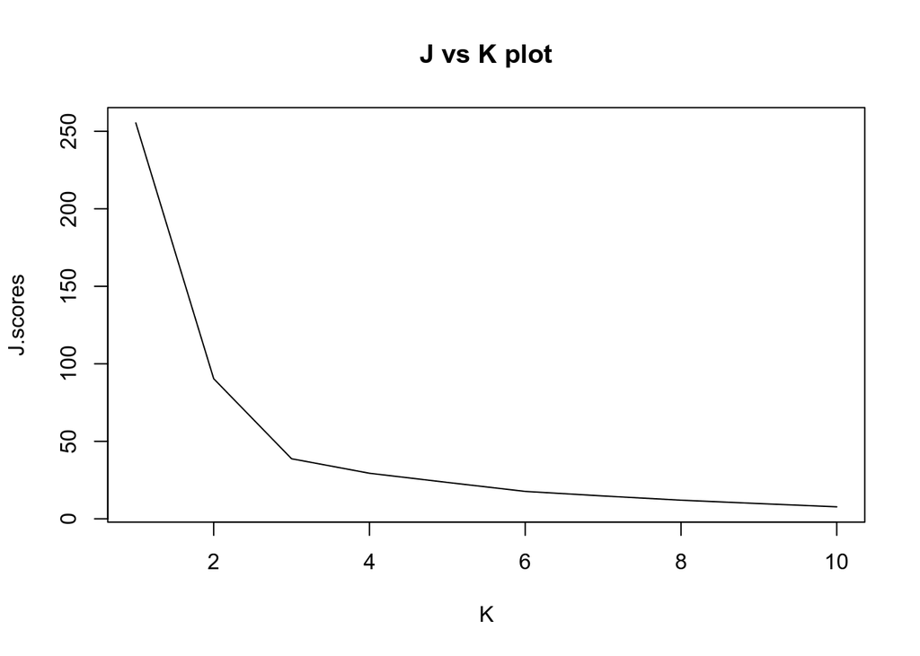

```r
plot(J.scores, type='l', main = "J vs K plot", xlab = "K")
```

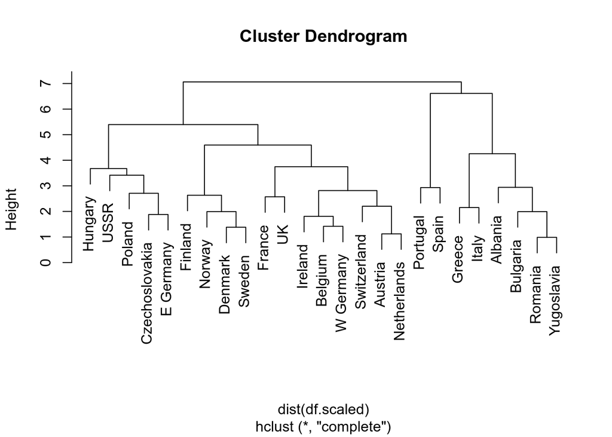

```r
res.hc <- hclust(dist(df.scaled), method="complete")
res.pam <- pam(df.scaled, 3)
plot(res.hc)
```

6. Cut the tree such that you get three clusters and compare your results with the k-medoids output with explanation.

```r
hc.clusters <- cutree(res.hc, 3)
pam.clusters <- res.pam$clustering

hc.clusters
```

```
##        Albania        Austria        Belgium       Bulgaria Czechoslovakia
##              1              2              2              1              2
##        Denmark      E Germany        Finland         France         Greece
##              2              2              2              2              1
##        Hungary        Ireland          Italy    Netherlands         Norway
##              2              2              1              2              2
##         Poland       Portugal        Romania          Spain         Sweden
##              2              3              1              3              2
##    Switzerland             UK           USSR      W Germany     Yugoslavia
##              2              2              2              2              1
```

```r
pam.clusters
```

```
##        Albania        Austria        Belgium       Bulgaria Czechoslovakia
##              1              2              2              1              2
##        Denmark      E Germany        Finland         France         Greece
##              2              2              2              2              3
##        Hungary        Ireland          Italy    Netherlands         Norway
##              1              2              3              2              2
##         Poland       Portugal        Romania          Spain         Sweden
##              2              3              1              3              2
##    Switzerland             UK           USSR      W Germany     Yugoslavia
##              2              2              1              2              1
```

if the cluster id match TRUE - where clusters match, FALSE - where clusters don’t match There is a good amount of match between the two methods

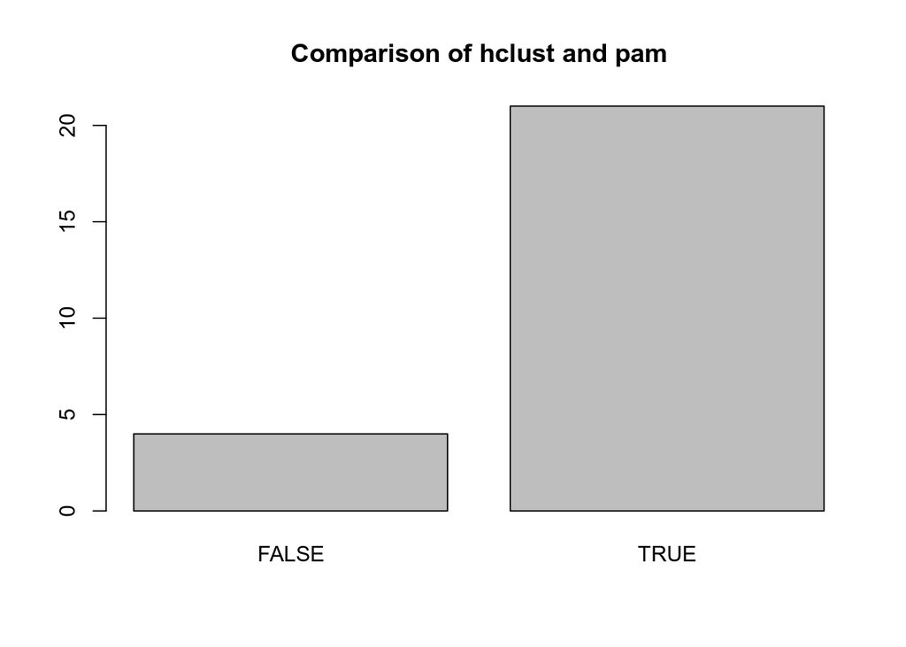

```r
diff <- ifelse((hc.clusters - pam.clusters) == 0, TRUE, FALSE)
barplot(table(diff), main = "Comparison of hclust and pam")
```